# Clustering (Part II)

Ryan Miller

## Review - Clustering Terminology

- The last presentation focused on $k$-means, a **partitional** clustering method that is **prototype-based**
  - *Partitional* meant it distinctly divided the data-points into non-overlapping subsets (clusters)
  - *Prototype-based* meant that each cluster is based upon a prototype (in $k$-means these are the *centroids*, or multi-dimensional means)
- Today we will cover two topics:
  - How to accommodate categorical variables into clustering
  - **Hierarchical** clustering methods (which aren’t necessarily partitional and are not prototype-based)

## Review - Distance

- Recall that “good” clusters should contain data-points that are similar (close) to each other, and dissimilar (far) from data-points in other clusters
- We’ve measured “closeness” using **Euclidean distance**:
  $$d_{a,b} = \sqrt{\sum_{j = 1}^{p} (x_{aj} - x_{bj})^2}$$
- We could represent the closeness of the $n$ data-points in a dataset using an $n$-by-$n$ **distance matrix**, for example:

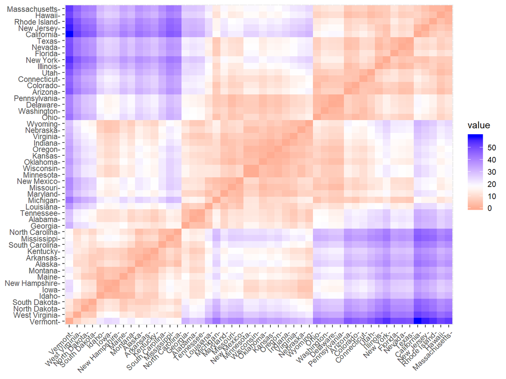

```r
USA2 <- select(USArrests, "UrbanPop", "Murder")
distance <- get_dist(USA2)
fviz_dist(distance)
```

## Example - Clustering Animals

- The `animals` dataset in the `cluster` package contains six binary categorical features describing 20 different animals, the dataset is shown below:

|  | Warm-blooded? | Can_fly? | Vertebrate? | Endangered? | Lives_in_groups? | Has_hair? |
| --- | --- | --- | --- | --- | --- | --- |
| ant | No | No | No | No | Yes | No |
| bee | No | Yes | No | No | Yes | Yes |
| cat | Yes | No | Yes | No | No | Yes |
| cpl | No | No | No | No | No | Yes |
| chi | Yes | No | Yes | Yes | Yes | Yes |
| cow | Yes | No | Yes | No | Yes | Yes |
| duc | Yes | Yes | Yes | No | Yes | No |
| eag | Yes | Yes | Yes | Yes | No | No |
| ele | Yes | No | Yes | Yes | Yes | No |
| fly | No | Yes | No | No | No | No |
| fro | No | No | Yes | Yes | NA | No |
| her | No | No | Yes | No | Yes | No |
| lio | Yes | No | Yes | NA | Yes | Yes |
| liz | No | No | Yes | No | No | No |
| lob | No | No | No | No | NA | No |
| man | Yes | No | Yes | Yes | Yes | Yes |
| rab | Yes | No | Yes | No | Yes | Yes |
| sal | No | No | Yes | No | NA | No |
| spi | No | No | No | NA | No | Yes |
| wha | Yes | No | Yes | Yes | Yes | No |

## Example - Clustering Animals

- The `daisy` function with the argument `metric = "gower"` can be used to find the distance matrix using Gower distance
- We can then visualize that matrix using `fviz_dist`:

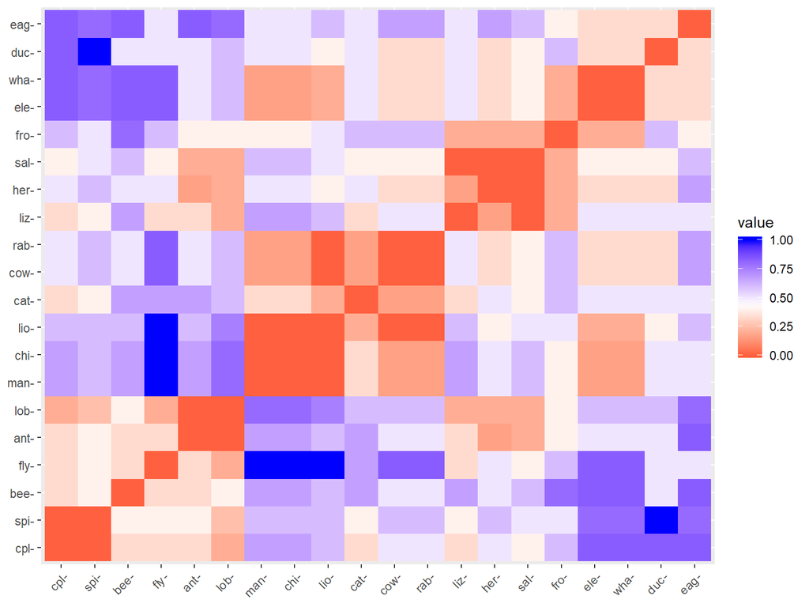

```r
D <- daisy(as.data.frame(animals), metric = "gower")
fviz_dist(D)
```

## Example - Clustering Animals

- Unfortunately Gower distance can’t be used for $k$-means clustering, as centroids remain uncalculable (though some hybrid approaches have been proposed)
- However, we can perform $k$-medoids clustering (often referred to as PAM, or Partitioning Around Medoids)
  - In PAM the prototypes are themselves data-points
  - Otherwise PAM is very similar to $k$-means, it is a partitional prototype-based method

## Example - Clustering Animals

- PAM clusters can only be visualized via a scatterplot when all of the involved variables are numeric
- When the data include categorical predictors, the best representation can provide is the medoids themselves along with a silhouette plot:

```r
D <- daisy(as.data.frame(animals), metric = "gower")
pm <- pam(D, k = 4)

# Print the medoids then plot the silhouettes
pm$medoids
```

```
## [1] "lob" "lio" "wha" "sal"
```

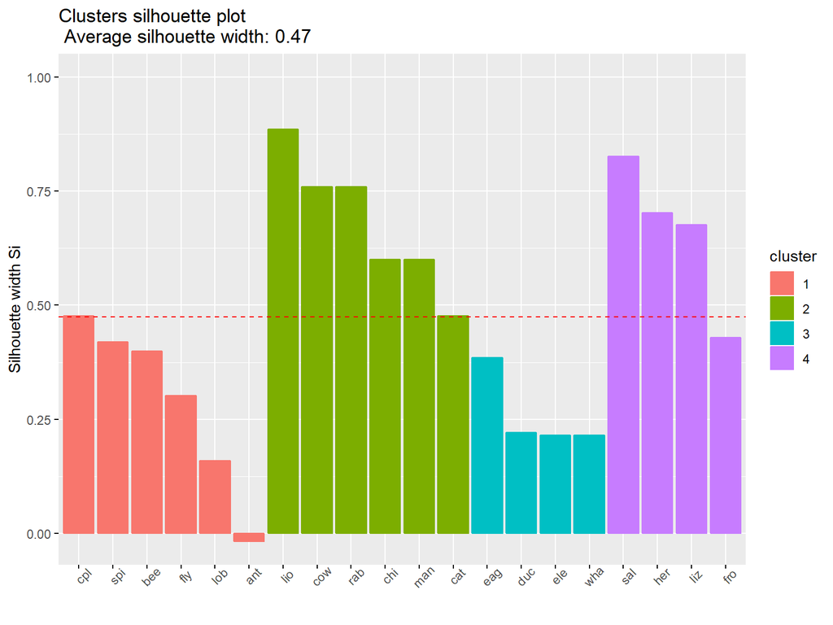

```r
fviz_silhouette(silhouette(pm), label = TRUE, print.summary = FALSE)
```

## Hierarchical Clustering

- We’ll now transition into a completely different approach to clustering
- Rather than creating distinct partitions of the data-points, we’ll instead organize them into a nested tree-like structure known as a **dendrogram**:

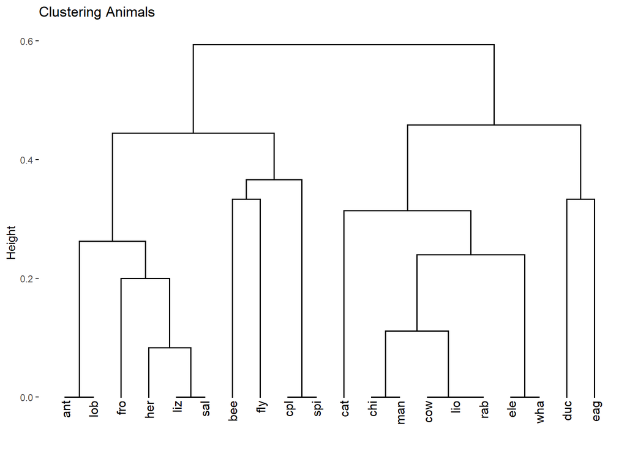

- We can view the dendrogram as a series of nested clusters, the first *branch* seperates $\{\text{ant, lob, fro,} \ldots \text{spi}\}$ from $\{\text{cat, man, cow,} \ldots, \text{eag}\}$
  - Each of these clusters can than be sub-divided by moving down the tree
  - The height at which two sub-clusters are merged reflects the average distance between those clusters

## Hierarchical Clustering

- A strength of heirarchical clustering is that it displays nested relationships (ie: clusters, sub-clusters, sub-sub-clusters, etc.)
  - Nevertheless, we can always *cut* a dendrogram to obtain non-overlapping clusters

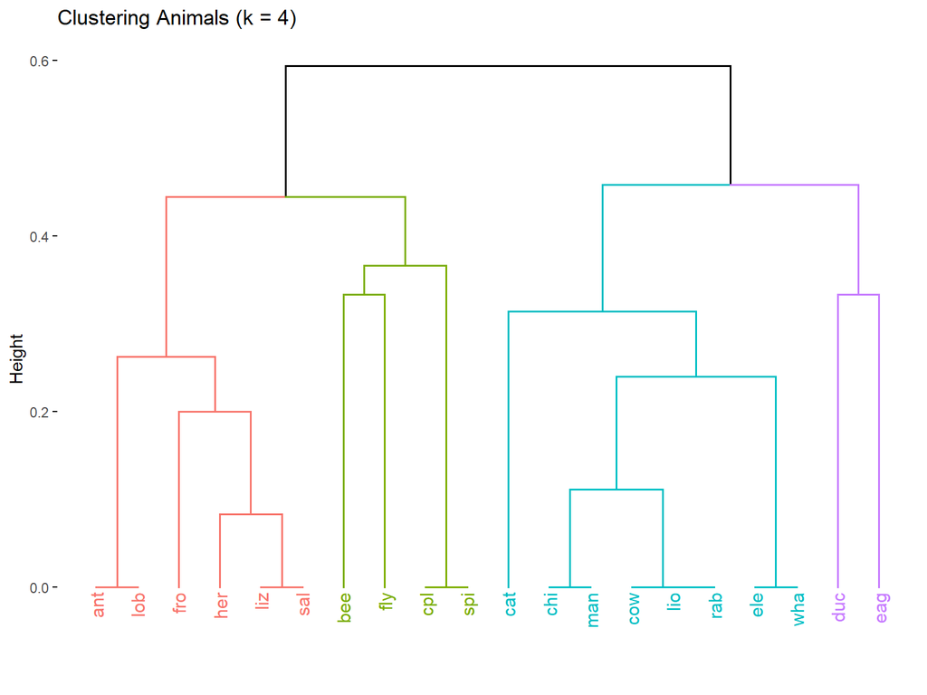

```r
fviz_dend(ag, k = 4) + labs(title = "Clustering Animals (k = 4)")
```

## Hierarchical Clustering - Algorithms

- There are two broad approaches to hierarchical clustering (ie: creating a dendrogram)
  - **Agglomerative**, or “bottom-up” approaches, which start with each data-point as its own cluster (leaf), and then combine similar clusters (branches) until all of the data-points are grouped together in single cluster (root)
  - **Divisive**, or “top-down” approaches, which start all of the data-points in a single cluster (root); this cluster is then divided into smaller clusters (branches) based upon dissimilarity, divisions continue until each data-point is its own cluster.
- The acronyms AGNES (AGglomerative NESting) and DIANA (DIvisive ANAlysis) describe two of the most popular of these approaches

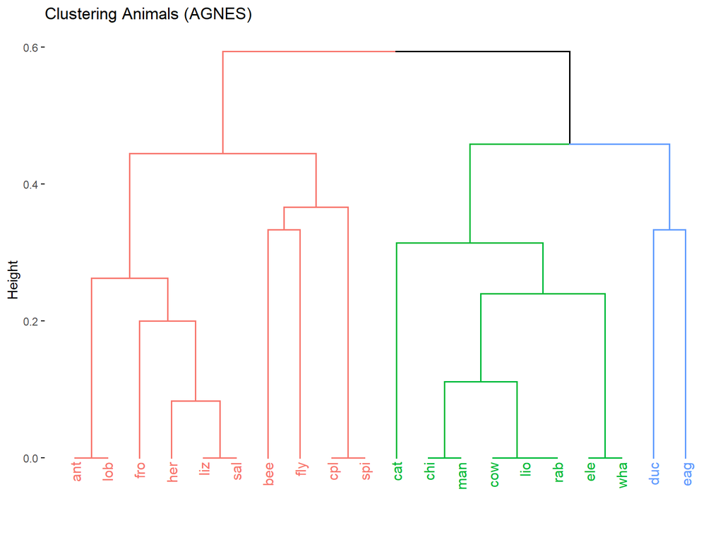

```r
D <- daisy(as.data.frame(animals), metric = "gower")

ag <- agnes(D)
fviz_dend(ag, k = 3) + labs(title = "Clustering Animals (AGNES)")
```

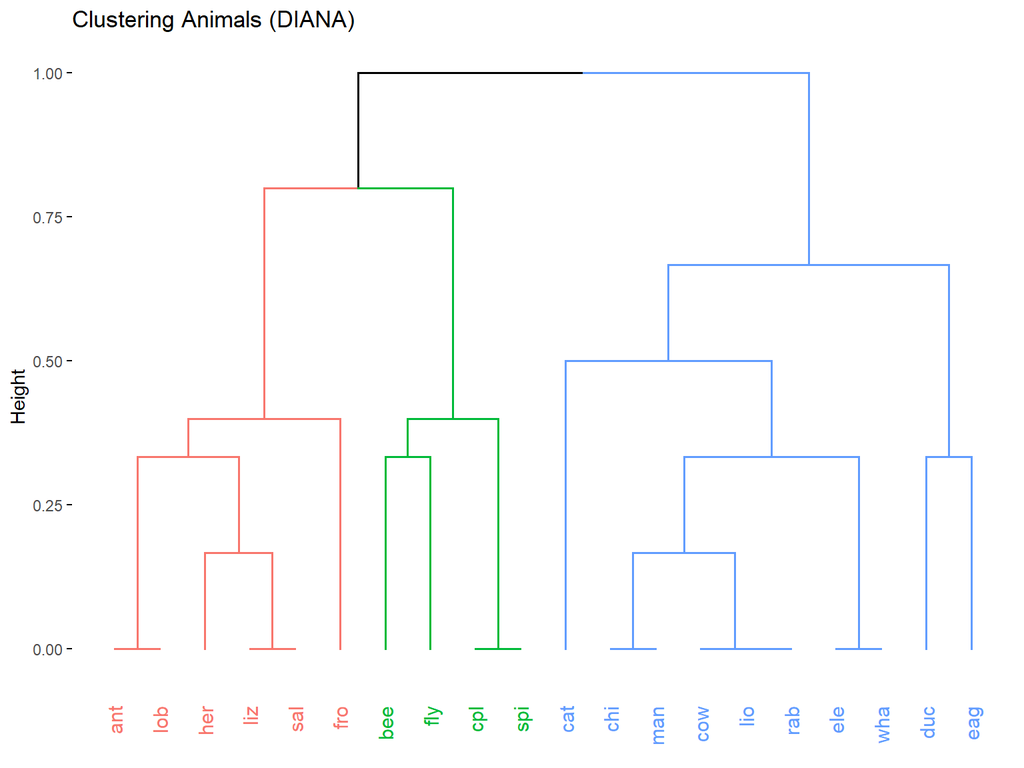

```r
di <- diana(D)
fviz_dend(di, k = 3) + labs(title = "Clustering Animals (DIANA)")
```

## Hierarchical Clustering - Closing Remarks

- Because hierarchical clustering algorithms are greedy, divisive and agglomerative approaches rarely yield the same results
  - Agglomerative algorithms are much more computationally efficient (fewer splits to check), and consequently tend to be more widely used
- We won’t fully explore the AGNES or DIANA algorithms, but you can find more details on them (as well as other clustering methods we don’t have time to cover) in this reference: https://www-users.cs.umn.edu/~kumar001/dmbook/ch8.pdf (start at page 516 for Hierarchical Clustering)